# Exercice 5 : personnalisation du format HTML

Télécharger le code source du document Exercice_5_HTML.Rmd et l’enregistrer dans un dossier pertinent.

Ouvrir le fichier dans votre éditeur de texte favori.

Compiler le fichier.

Dans l’en-tête du document, ajouter un `:` après l’option `html_document`. Le `:` indique au compilateur qu’une option de niveau inférieur suivra.

Faire un retour à la ligne et une tabulation, puis ajouter l’option `toc: TRUE` sous `html_document:`.

L’en-tête résultante est illustrée ci-bas. Attention! Le respect de l’indentation et des `:` est essentiel.

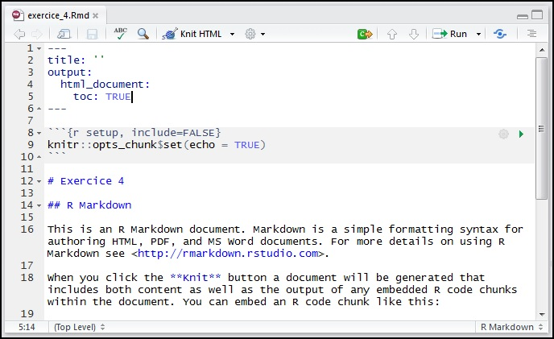

Compiler le document à nouveau, puis observer les changements (indice : table des matières).

**Fermer le document HTML, car R Markdown sera incapable d’effectuer des modifications à celui-ci s’il est toujours ouvert au moment de la prochaine compilation.**

Ajouter l’option `toc_float: TRUE` sous `toc: TRUE` :

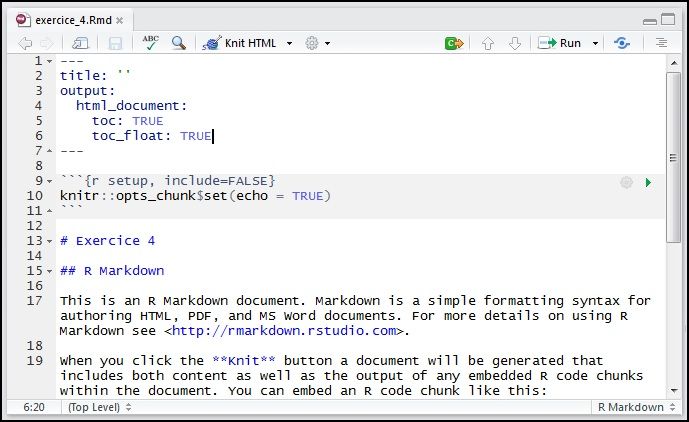

Compiler le document à nouveau, puis observer les changements.

**À nouveau, après avoir consulté les modifications, fermer le document HTML, car R Markdown sera incapable d’effectuer des modifications à celui-ci s’il est toujours ouvert au moment de la prochaine compilation.**

Faire défiler le document pour constater l’effet de la table des matières flottante.

De la même façon que la ligne précédente, ajouter la ligne `number_sections: TRUE` à l’en-tête, compiler le résultat, et observer les changements.

Fermer le document HTML.

De la même façon que la ligne précédente, ajouter la ligne `theme: flatly` à l’en-tête, compiler le résultat, et observer les changements.

Fermer le document HTML.

De la même façon que la ligne précédente, ajouter la ligne `highlight: espresso` à l’en-tête, compiler le résultat, et observer les changements.

Fermer le document HTML.

Le résultat final du code source devrait être le suivant :

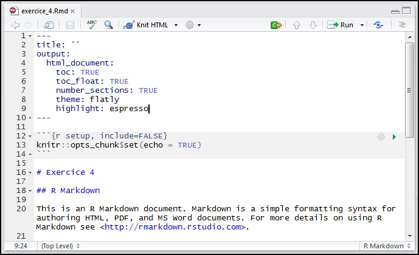

Pour un guide plus complet des fonctionnalités HTML, consulter la page à ce sujet sur le site de R Markdown : [Options du format HTML en R Markdown](http://rmarkdown.rstudio.com/html_document_format.html)